# ESM204 HW2 Simulating a Water Market

Sarah Lam and Logan Ossentjuk

```r
knitr::opts_chunk$set(echo = TRUE, message = FALSE, warning = FALSE)
library(tidyverse)
library(here)
library(effsize)
library(kableExtra)
library(broom)
```

```r
# Read in the data
water_curves <- read_csv("Water_Districts.csv")
```

Agricultural water is managed by irrigation districts and is increasingly scarce. To conserve water and reduce costs, four irrigation districts are considering developing a water market, in which water rights would be traded across the districts. In this homework you will conduct data analysis, simulations, and policy analysis to help inform the development of the water market. The dataset for this assignment is available in the file “Water_Districts.csv”, available on Gauchospace. The dataset contains estimates of the marginal cost of reducing water use in each of the four irrigation districts (Kern, Mojave, Antelope, and Ventura) for different levels of reduction (in Acre Feet). A few notes: - Current (i.e. baseline) water use in these districts1 is: Kern = 150 AF, Mojave = 140 AF, Antelope = 220 AF, and Ventura = 245 AF. - Prices are in $/Acre Foot and quantities are in Acre Feet (AF). Please write a concise report that addresses all of the points below.

#### 1. Marginal Abatement Cost Curves

**For each irrigation district, plot the marginal abatement cost data (from the data provided) and estimate a linear regression model with zero intercept. These estimated linear regressions will be your estimates of the marginal abatement cost curve (one for each irrigation district), which you will use for the remainder of this analysis.** .

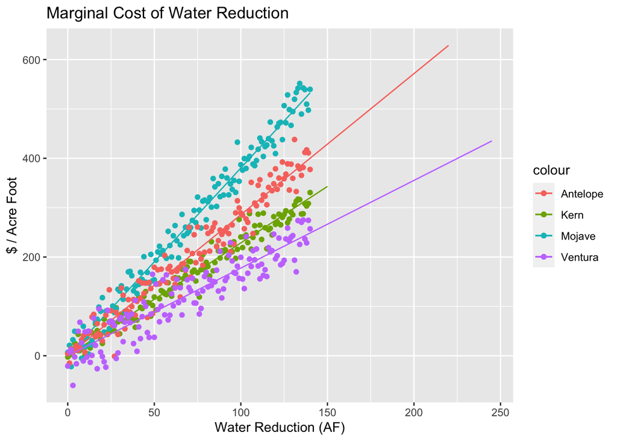

```r
#regression lines and marginal cost plots
ggplot() +
  geom_point(data = water_curves, aes(x = Reduction, y = MC_Kern, color = "Kern")) +
  geom_line(data = kern_data, aes(x=Reduction, y=predicted_MC, color = "Kern")) +
  geom_point(data = water_curves, aes(x = Reduction, y = MC_Mojave, color = "Mojave")) +
  geom_line(data = mojave_data, aes(x=Reduction, y=predicted_MC, color = "Mojave")) +
  geom_point(data = water_curves, aes(x = Reduction, y = MC_Antelope, color = "Antelope")) +
  geom_line(data = antelope_data, aes(x=Reduction, y=predicted_MC, color = "Antelope")) +
  geom_point(data = water_curves, aes(x = Reduction, y = MC_Ventura, color = "Ventura")) +
  geom_line(data = ventura_data, aes(x=Reduction, y=predicted_MC, color = "Ventura")) +
  labs(y = "$ / Acre Foot",
       x = "Water Reduction (AF)",
       title = "Marginal Cost of Water Reduction")
```

#### 2. Demand Curves

**Using your estimated marginal abatement cost curves, derive each district’s demand curve for water. In other words, how much would each district be willing to pay for the right to use the first AF of water, second AF, etc.? Plot each district’s demand curve on a single graph. Which sector is willing to pay the most for the first AF of water?**

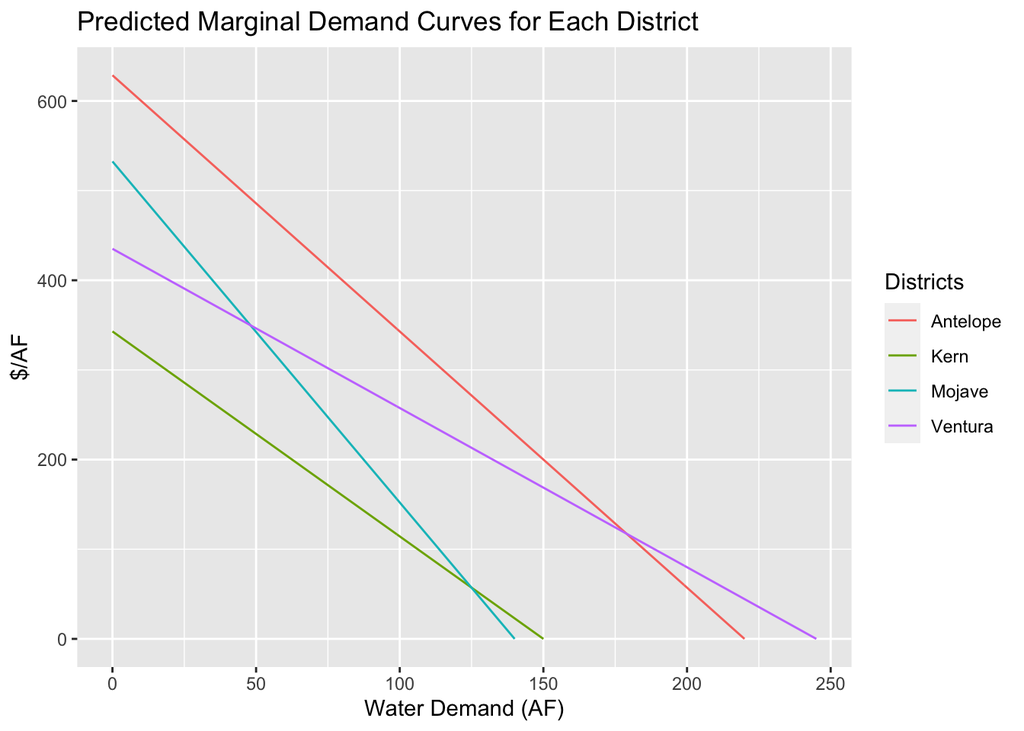

```r
#### We want the data for all districts to be in one plot now
joined_demand <- bind_rows('Mojave' = mojave_data,
                           'Kern' = kern_data,
                           'Antelope' = antelope_data,
                           'Ventura' = ventura_data, .id = 'Districts')
### plot the demand curves
ggplot(data = joined_demand, aes(x = water_demand, y = predicted_MC, color = Districts)) +
  geom_line() +
  labs(title = "Predicted Marginal Demand Curves for Each District",
       x = "Water Demand (AF)",
       y = "$/AF")
```

Antelope has the highest willingness to pay for the first AF of water.

#### 3. Alternative Water Policies

**Here you will analyze three alternative policies for reducing water use among these irrigation districts. In total, these irrigation districts will need to reduce water consumption from the current 755 AF down to 500 AF. For each intervention listed below, perform the following calculations: (1) calculate the stringency of the policy (defined below for each intervention) required to achieve the 500 AF target, (2) calculate the total cost of meeting the target using that approach, (3) calculate the cost to each district, and (4) calculate the tax revenue generated.**

**a. Cap without trade. Reduce each district’s water use by the same fraction (e.g., 1/3 of current baseline use), so the 500 AF target is met. Trade is not allowed. Stringency is defined as the magnitude of the fraction.**

**1) Stringency of the policy**

755-500 = 255.

p(150) + p(140)+ p(220) + p(245) = 255

p = 0.338

**2) Total cost of meeting the target:**

$2938.55 + $4278.78 + $7900.53 + $6089.61 = $21207.47

**3) Cost to each district:**

```r
# A function to compute the cost for a districts abatement given the abatement number
quantity_abate = 50
lm_mod = mod_kern
# defining the function
calc_cost <- function(lm_mod, quantity_abate) {
  estimated_cost = lm_mod$coefficients * quantity_abate
  total_cost = 0.5 * quantity_abate * estimated_cost
  return(total_cost[[1]])
}

calc_est <- function(lm_mod, quantity_abate) {
  estimated_cost = lm_mod$coefficients * quantity_abate
  return(estimated_cost[[1]])
}

# Q3a, kern abated 0.338 * 150 = 50.7 units
kern_cost <- calc_cost(mod_kern, quantity_abate = 50.7)
mojave_cost <- calc_cost(mod_mojave, quantity_abate = 47.43)
antelope_cost <- calc_cost(mod_antelope, quantity_abate = 74.36)
ventura_cost <- calc_cost(mod_ventura, quantity_abate = 82.81) #these calculations are the same thing as if we calculated the area under the curve using the area of a triangle

kern_est <- calc_est(mod_kern, quantity_abate = 50.7)
mojave_est <- calc_est(mod_mojave, quantity_abate = 47.43)
antelope_est <- calc_est(mod_antelope, quantity_abate = 74.36)
ventura_est <- calc_est(mod_ventura, quantity_abate = 82.81)

district_costs <- tibble(kern_cost, mojave_cost, antelope_cost, ventura_cost) #put costs into nice table
district_costs %>%
  kableExtra::kable(col.names = c("Kern",
                                  "Mojave", "Antelope", "Ventura")) %>%
   kable_styling(full_width = FALSE)
```

| Kern | Mojave | Antelope | Ventura |
| --- | --- | --- | --- |
| 2938.55 | 4278.783 | 7900.534 | 6089.608 |

**4) Tax Revenue:**

There will be no tax revenue generated because there is no tax here.

**b. Tax on water use.**

A single tax is implemented on all water use in each of the four districts, such that water use is reduced to the 500 AF target. Stringency is defined as the magnitude of the tax.

We started by graphing the aggregate of the marginal cost curves for each water district. We did this by finding the slope of the aggregate line.

Kern: P = 2.29A

Antelope: P = 2.86A

Ventura: P = 1.78A

MCagg = A(1/2.29 +1/3.9 +1/2.86 + 1/1.78)

A = .621, this is our slope of the aggregate line which we can graph using abline()

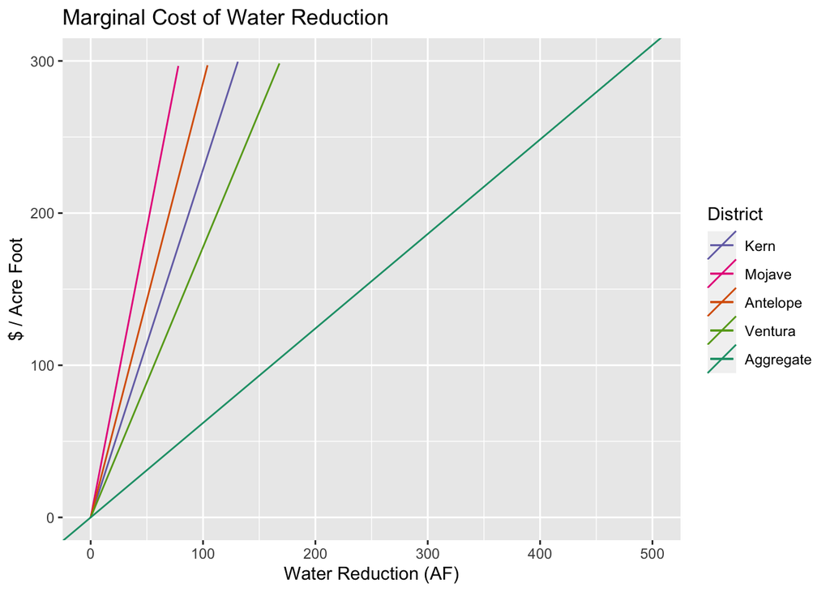

```r
ggplot() +
  geom_line(data = kern_data, aes(x=Reduction, y=predicted_MC, color = "Kern")) +
  geom_line(data = mojave_data, aes(x=Reduction, y=predicted_MC, color = "Mojave")) +
  geom_line(data = antelope_data, aes(x=Reduction, y=predicted_MC, color = "Antelope")) +
  geom_line(data = ventura_data, aes(x=Reduction, y=predicted_MC, color = "Ventura")) +
  geom_abline(aes(intercept = 0, slope = 0.621, colour = "Aggregate")) +
  scale_color_brewer(palette = "Dark2",
                     breaks = c("Kern", "Mojave", "Antelope", "Ventura", "Aggregate")) +
  xlim(0,500) +
  ylim(0,300) +
  labs(y = "$ / Acre Foot",
       x = "Water Reduction (AF)",
       title = "Marginal Cost of Water Reduction",
       col = "District")
```

**1) Stringency of the policy**

The tax should be set at $158.36 for a reduction of 255 AF.

```r
aggMC <- function(x){
  return(0.621*x)
}
aggMC(255)
```

**2) calculate the total cost of meeting the target using that approach**

The total cost of the policy is the area under the aggregate line up to the reduction amount plus the quanity used times the marginal cost.

```r
(255 * 158.355 * .5) + (500 * 158.355)
```

**3) calculate the cost to each district**

The cost to each district is the area under the marginal cost curve for each district at the amount of the tax ($158.36) plus the cost of water used (tax*amount of water).

Kern: Cost of tax * amount of water: (150 - (158.355/2.29)) * 158.36 = $12,803.30

Cost of abatement: 158.355/2.29 * 158.355 * 0.5 = $5,475.349

*Total cost: $18,278.65*

Mojave: Cost of tax * amount of water: (140 - (158.355/3.8)) * 158.36 = 15,571.16

Cost of abatement: 158.355/3.8 * 158.355 * 0.5 = 3,299.618

*Total cost: $18,870.78*

Antelope: Cost of tax * amount of water: (220 - (158.355/2.86)) * 158.36 = 26,070.98

Cost of abatement: 158.355/2.86 * 158.355 * 0.5 = 4,384.108

*Total cost: $30,455.09*

Ventura: Cost of tax * amount of water: (245 - (158.355/1.78)) * 158.36 = 24,709.94

Cost of abatement: 158.355/1.78 * 158.355 * 0.5 = 7,044.129

*Total cost: $31,754.07*

```r
#kern
158.355/2.29 * 158.355 * 0.5
(150 - (158.355/2.29)) * 158.355
(158.355/2.29 * 158.355 * 0.5) + ((150 - (158.355/2.29)) * 158.355)

#mojave
158.355/3.8 * 158.355 * 0.5
(140 - (158.355/3.8)) * 158.355
(158.355/3.8 * 158.355 * 0.5) + (140 - (158.355/3.8)) * 158.355

#antelope
158.355/2.86 * 158.355 * 0.5
(220 - (158.355/2.86)) * 158.355
(158.355/2.86 * 158.355 * 0.5) + ((220 - (158.355/2.86)) * 158.355)

#ventura
158.355/1.78 * 158.355 * 0.5
(245 - (158.355/1.78)) * 158.355
(158.355/1.78 * 158.355 * 0.5) + (245 - (158.355/1.78)) * 158.355

#Summing costs
8278.65 + 18870.78 + 30455.09 + 31754.07 #99358.59
```

**4) Calculate the tax revenue generated.**

The tax revenue generated is the entire area of the reduction times the amount of the tax (Q* x T*).

```r
#Tax Revenue:
255 * 158.36
```

**c. Cap and trade. Cap water use as in part (a), but after those caps are set, allow trade across districts. How much water is used by each district after trade? Stringency is the same as in part (a).**

**1) Stringency of the policy**

Kern: (158.355/2.29)/kern_baseline = 0.4610044

Mojave: (158.355/3.8)/mojave_baseline = 0.2976598

Antelope: (158.355/2.86)/antelope_baseline = 0.2516767

Ventura: (158.355/1.78)/ventura_baseline = 0.3631163

```r
#kern
(158.355/2.29)/kern_baseline #0.4610044
#mojave
(158.355/3.8)/mojave_baseline #0.2976598
#antelope
(158.355/2.86)/antelope_baseline #0.2516767
#ventura
(158.355/1.78)/ventura_baseline #0.3631163
```

**2) calculate the total cost of meeting the target using that approach**

The total cost of the cap with trade policy is $20,190.26

```r
158.355 * 255 * .5
```

**3) calculate the cost to each district** The cost to each district is the area under the marginal cost curve at the price of the equimarginal principle plus or minus the difference between the marginal price of abatement and the equimarginal price for each district before trade.

Kern: $5,083.878

Mojave: $3,503.216

Antelope: $4,883.542

Ventura: $6,940.063

```r
#Kern
(158.355/2.29 * 158.36 * 0.5) - ((69.15-50.7)*(158.355-kern_est)*.5)

#Mojave
(158.355/3.8 * 158.36 * 0.5) - ((69.15-50.7)*(158.355-180.4252)*0.5)

#Antelope:
(158.355/2.86 * 158.36 * 0.5) - ((69.15-50.7)*(158.355-212.4942)*0.5)

#Ventura:
(158.355/1.78 * 158.36 * 0.5) - ((69.15-50.7)*(158.355-ventura_est)*0.5)
```

**4) Tax Revenue:**

There is no tax revenue generated because there is no tax.

#### 4. Water reduction after drought

**A severe drought hits California, and it is necessary to reduce water use from 500 AF down to 300 AF. Your job is to estimate the cost of the drought (i.e., the cost of reducing water use from 500 AF to 300 AF) to each irrigation district under each policy. Considering the entire jump from status quo (755 AF) to the drought (300 AF), which policy is preferred by each irrigation district? How does your answer depend on how rights are allocated to each district (in policies (a) and (c))?**

**Drought Reduction Cap without trade.** **Stringency of the policy**

755-300 = 455.

p(150) + p(140)+ p(220) + p(245) = 455

p = 0.603

**Cost to each district:**

```r
# A function to compute the cost for a districts abatement given the abatement number
quantity_abate = 50
lm_mod = mod_kern

# Q4, kern abated  0.603 * 150 = 90.45 units, and so on for each district
kern_cost_603 <- calc_cost(mod_kern, quantity_abate = 90.45)
mojave_cost_603 <- calc_cost(mod_mojave, quantity_abate = 84.42)
antelope_cost_603 <- calc_cost(mod_antelope, quantity_abate = 132.66)
ventura_cost_603 <- calc_cost(mod_ventura, quantity_abate = 147.735) #these calculations are the same thing as if we calculated the area under the curve using the area of a triangle

calc_est_603 <- function(lm_mod, quantity_abate) {
  estimated_cost = lm_mod$coefficients * quantity_abate
  return(estimated_cost[[1]])
}

# Q4, kern abated  0.603 * 150 = 90.45 units, and so on for each district
calc_est_603(mod_kern, quantity_abate = 90.45)
calc_est_603(mod_mojave, quantity_abate = 84.42)
calc_est_603(mod_antelope, quantity_abate = 132.66)
calc_est_603(mod_ventura, quantity_abate = 147.735)
```

```r
district_costs_603 <- tibble(kern_cost_603, mojave_cost_603, antelope_cost_603, ventura_cost_603) #put costs into nice table
district_costs_603 %>%
  kableExtra::kable(col.names = c("Kern",
                                  "Mojave", "Antelope", "Ventura")) %>%
   kable_styling(full_width = FALSE)
```

| Kern | Mojave | Antelope | Ventura |
| --- | --- | --- | --- |
| 9352.641 | 13555.16 | 25145.35 | 19381.64 |

**Drought Reduction with tax**

The tax should be set at $282.56 for a reduction of 455 AF.

```r
aggMC(455) #marginal cost of water reduction when use is limited to 300 AF (455 AF reduction)
```

**3) calculate the cost to each district**

Kern: Total cost: $24,951.52

Antelope: Total cost: $48,204.53

Ventura: Total cost: $46,799.76

```r
#kern
(282.555/2.29 * 282.555 * 0.5) + ((150 - (282.555/2.29)) * 282.555)

#mojave
(282.555/3.8 * 282.555 * 0.5) + ((140 - (282.555/3.8)) * 282.555)

#antelope
(282.555/2.86 * 282.555 * 0.5) + ((220 - (282.555/2.86)) * 282.555)

#ventura
(282.555/1.78 * 282.555 * 0.5) + ((245 - (282.555/1.78)) * 282.555)
```

**Drought reductions with cap and trade.**

**Cost to each district**

Kern: $18,130.55

Mojave: $9,562.764

Antelope: $13,311.26

Ventura: $22,612.29

```r
#Kern
(282.555/2.29 * 282.555 * 0.5) + ((69.15-50.7)*(282.555-206.8024)*.5)

#Mojave
(282.555/3.8 * 282.555 * 0.5) - ((69.15-50.7)*(282.555-180.4252)*0.5)

#Antelope:
(282.555/2.86 * 282.555 * 0.5) - ((69.15-50.7)*(282.555-212.4942)*0.5)

#Ventura:
(282.555/1.78 * 282.555 * 0.5) + ((69.15-50.7)*(282.555-262.3839)*.5)
```

Considering a reduction in water use from 755 to 300 AF, the tax scenario is the most expensive option for all districts. While the cap with trade policy is the lowest total cost option, both Kern and Ventura would prefer a cap without trade policy that would cost them less overall. However Mojave and Antelope would prefer a cap with trade policy as that is the least cost option for those districts.These preferences are based on an initial cap of equal proportion of reduction. Allocating water use limits at different initial proportions, either through grandfathering or another method, would result in different preferred scenarios for each district.